# Summary of analysis results

juliaapolonio/MR_workflow version 0.1.0dev

outubro 21, 2024

# 1 Abstract

The bioinformatics analysis pipeline [juliaapolonio/MR_workflow](https://github.com/juliaapolonio/MR_workflow/) is a pipeline for Mendelian Randomization and sensitivity analysis between a given GWAS sumstats and QTL data.

# 2 Pipeline Results

## 2.1 Forest Plot

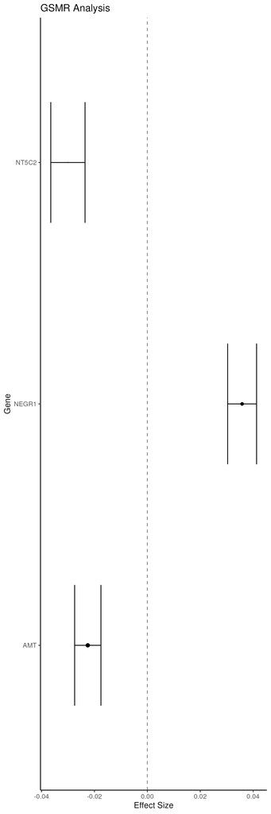

## 2.2 Volcano Plot

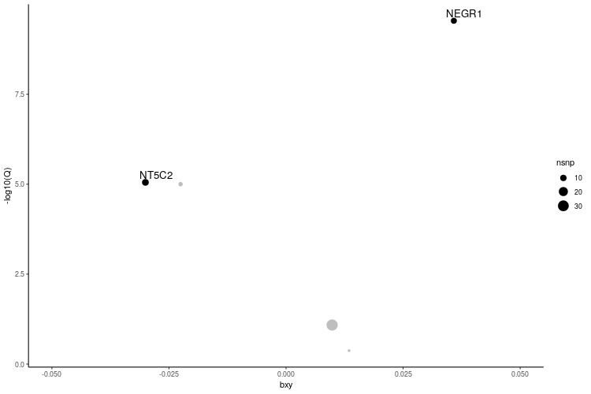

|  | gene | nsnp | b_Inverse_variance_weighted | pval_Inverse_variance_weighted | gsmr_beta | gsmr_pval | causal_snp |
| --- | --- | --- | --- | --- | --- | --- | --- |
| 1 | NEGR1 | 4 | 0.0307088 | 0.0247508 | 0.0358321 | 5.74826e-11 | rs10789340 |
| 3 | NT5C2 | 8 | -0.0293446 | 0.0007924 | -0.0300312 | 3.56134e-06 | rs732998 |

# 3 Nextflow and pipeline information

Technical information to the pipeline run are collected in folder pipeline_info, including software versions collected at runtime in file `software_versions.yml` (can be viewed with a text editor), all parameter settings in file `params_{date}_{time}.json` (can be viewed with a text editor), execution report in file `execution_report_{date}_{time}.html`, execution trace in file `execution_trace_{date}_{time}.txt`, execution timeline in file `execution_timelime_{date}_{time}.html`, and pipeline direct acyclic graph (DAG) in file `pipeline_dag_{date}_{time}.html`.

# 4 Final notes

This report (file `summary_report.html`) is located in folder summary_report of the original pipeline results folder. In this file, all links to files and folders are relative, therefore hyperlinks will only work when the report is at its original place in the pipeline results folder. Plots specifically produced for this report (if any) can be also found in folder summary_report.